# EDA on Medical Data of Thrombosis Diagnosis

Author

Aanchal Dusija

Published

February 21, 2023

Github url: https://github.com/anly503/hw2-spring-2023-aanchal-dusija

# Medical Data Desciption

At the university hospital, databases are collected. Each patient arrived at the collagen diseases outpatient clinic after being introduced by a few home doctors or general practitioners at the nearby hospitals. Patients with collagen illnesses develop antibodies that damage their bodies, making them auto-immune diseases. Only a portion of the illness mechanisms are understood, and it is still unclear how to categorize them. Some people may produce a variety of antibodies, and all the signs and symptoms of collagen illnesses may be present in their symptoms.

Thrombosis is one of the most serious complications, and one of the leading causes of death in collagen diseases. Recently, this complication has been linked to anti-cardiolipin antibodies, which were discovered by medical doctors, one of whom donated datasets for the discovery challenge.Thrombosis is a medical emergency, and it is critical to detect and predict the possibility of thrombosis.

The data is stored in three tables (tsumoto_a.csv, tsumoto_b.csv, tsumoto_c.csv) and the patients in these tables are connected by their ID number.The data used in the study includes information about the patients such as their identification, sex, birthday, description date, first date, admission, and diagnosis. There is also information about the examination date and results of aCL IgG and aCL IgM tests.

# Questions to investigate

1. How does the level of thrombosis relate to the average age and level of Creatinine?
2. What is the relationship between patient demographics (Sex, Admission) and the presence of Thrombosis, as measured by Age and Symptoms?
3. What is the relationship between the levels of Lactate Dehydrogenase (LDH) and the Years from the Thrombosis Test?
4. What is the relationship between levels of Uric Acid and Urea Nitrogen based on Thrombosis and Gender?

### Data Munging

```r
# Loading the Data
data1<-read.csv("data/TSUMOTO_A.csv", header = TRUE, sep=",",fileEncoding="latin1")
data2<-read.csv("data/TSUMOTO_B.csv",header = TRUE, sep=",",fileEncoding="latin1")
data3<-read.csv("data/TSUMOTO_C.csv",header = TRUE, sep=",", fileEncoding="latin1")
```

### Removing Duplicates Rows

```r
data1<-data1 %>% distinct() # all unique
data2<-data2 %>% distinct() # all unique
data3<-data3 %>% distinct() # 29 duplicates
```

### Replacing Space with an underscore and column names in lower case

```r
data1<-data1 %>%
  select_all(~gsub("\\s+|\\.", "_", .)) %>%
  select_all(tolower)

data2<-data2 %>%
  select_all(~gsub("\\s+|\\.", "_", .)) %>%
  select_all(tolower)

data3<-data3 %>%
  select_all(~gsub("\\s+|\\.", "_", .)) %>%
  select_all(tolower)
```

### Fill empty values with NA

```r
data1[data1==""]<-NA
data2[data2==""]<-NA
data3[data3==""]<-NA
```

# Data 1 Cleaning

```r
# checking duplicate ids
length(unique(data1$id)) == nrow(data1)
```

```
[1] FALSE
```

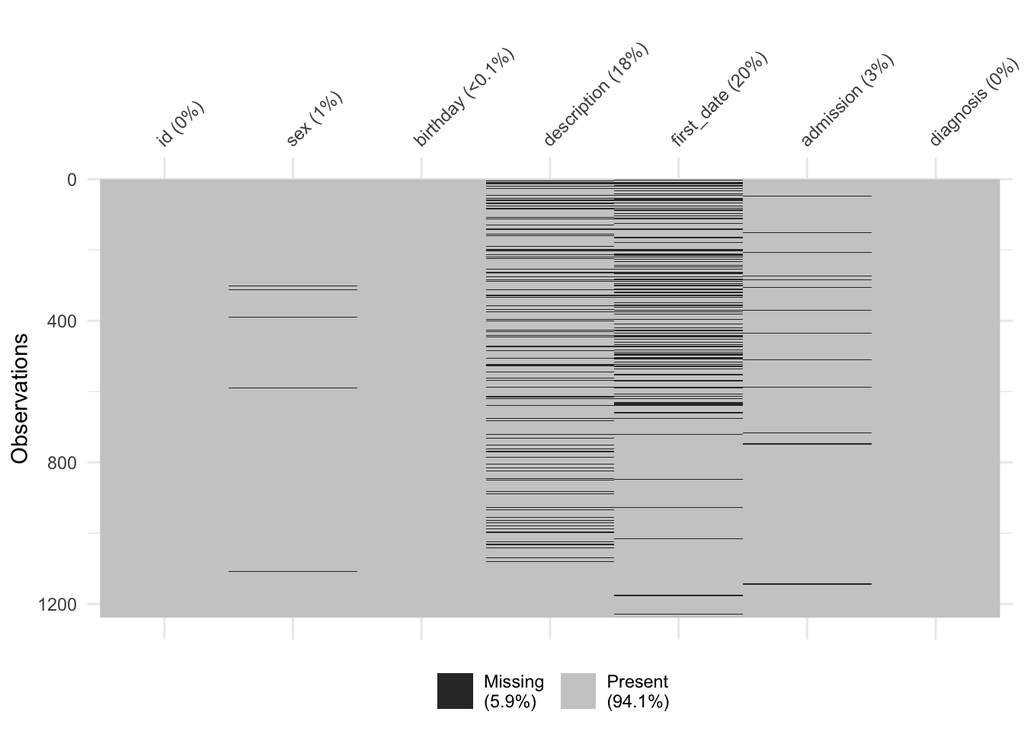

```r
# remove duplicate rows by id
data1<-distinct(data1, id, .keep_all = TRUE)

# converting sex to factor datatype
data1$sex<- as.factor(data1$sex)

# cleaning the admissions vector
data1$admission <- str_extract(string = data1$admission,pattern = "\\-|\\+")

# convert birthday to date format
data1$birthday<-as.Date(data1$birthday)

# Missing Values Proportion
visdat::vis_miss(data1)
```

```r
# Not Keeping Description Date, First Date Column and Diagnosis
data1<-data1[,-c(4,5,7)]
```

# Data 2 Cleaning

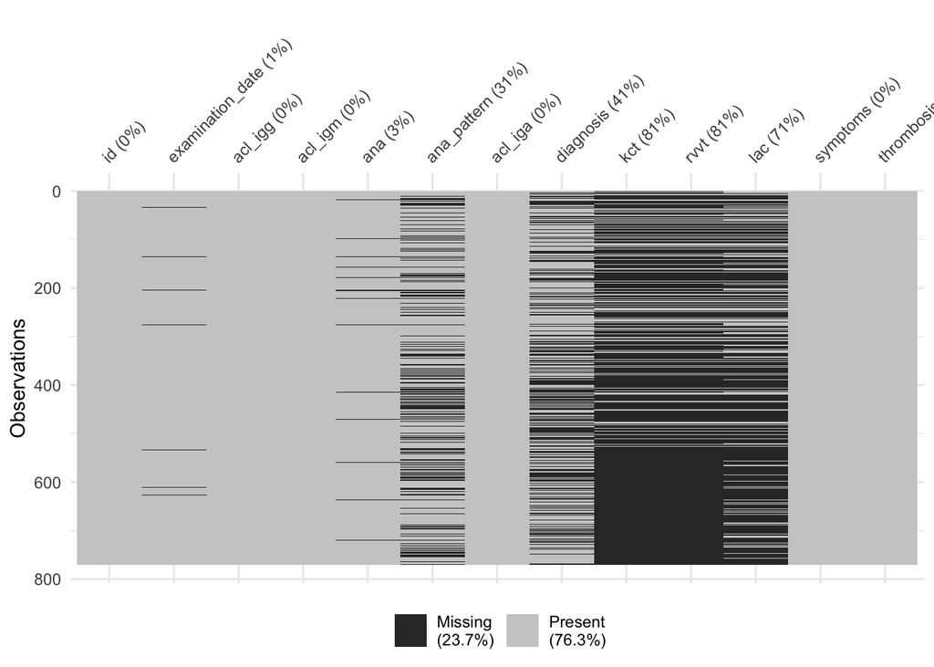

```r
# Adding values in symptom column
data2$symptoms[data2$thrombosis == '0'] <- "none"

# removing rows with no id
data2<-data2 %>% drop_na(id)

# Missing Values Proportion
visdat::vis_miss(data2)
```

```r
# symptoms data cleaning
data2$symptoms <- str_extract(string = data2$symptoms,pattern = "[[:ascii:]]*")
data2$ana <- parse_number(data2$ana)

# converting exam date format
data2$examination_date<-as.Date(data2$examination_date)

# empty spaces with NA
data2[data2==""]<-NA

# Creating thrombosis boolean column
data2$thrombosis_bol<-as.factor(ifelse(data2$thrombosis==0, 0,
        ifelse(data2$thrombosis==1, 1,
        ifelse(data2$thrombosis==2, 1,
        ifelse(data2$thrombosis==3, 1,
                        NA  )))))

# kct, lac and rvvt as boolean columns
data2$kct<-ifelse(data2$kct=="-", 1,
        ifelse(data2$kct=="+", 0,
                        NA  ))

data2$rvvt<-ifelse(data2$rvvt=="-", 1,
        ifelse(data2$rvvt=="+", 0,
                        NA  ))

data2$lac<-ifelse(data2$lac=="-", 1,
        ifelse(data2$lac=="+", 0,
                        NA  ))

# remove duplicate rows by id
data2<- distinct(data2, id, .keep_all = TRUE)

# error in spelling - thrombocytepenia - thrombocytopenia
data2$symptoms<-str_replace_all(data2$symptoms, "thrombocytepenia","thrombocytopenia")
data2$symptoms<-str_replace_all(data2$symptoms, "Abortion","abortion")

# keep only 1 symptom
data2$symptoms<- str_extract(data2$symptoms, "^[^,()]+")

# distribution of aCL IgG, aCL IgM, and aCL IgA are quite unusual: (typo maybe)
```

# Data 3 cleaning

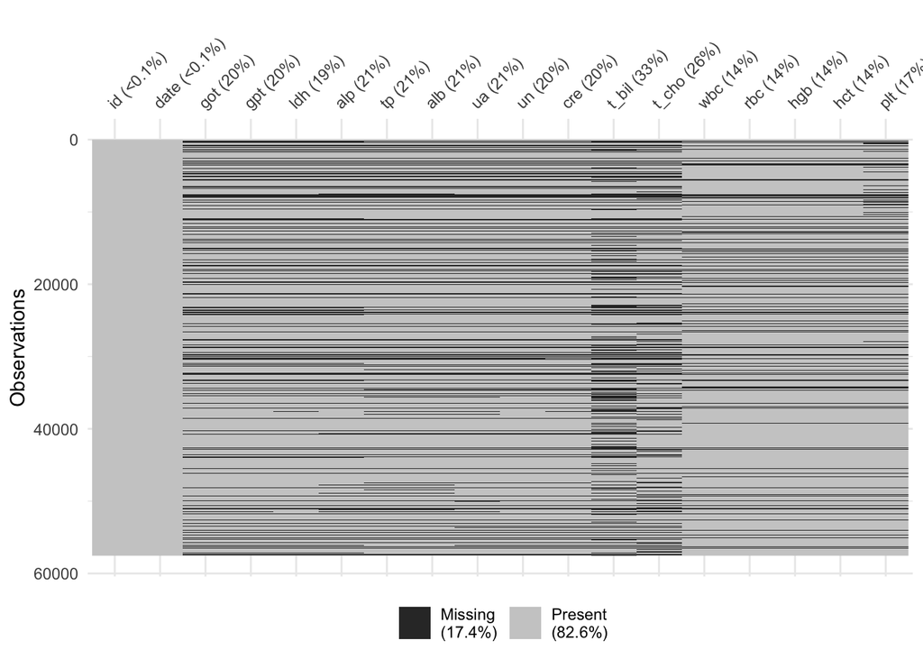

```r
# Removing columns with more than 40% empty values
data3 <- data3[,!colSums(is.na(data3))/nrow(data3) >= 0.4]
data3 <- data3[,-c(19,20)]

# Missing value plot
visdat::vis_miss(data3, warn_large_data = FALSE)
```

```r
# Convert date format
data3$date<-as.Date(data3$date, format = '%y%m%d')
data3<-data3 %>% mutate_if(is.character,as.numeric)

# drop rows with no id
data3<-data3 %>% drop_na(id)

# Fill missing values of numeric data
data3 <- data3 %>% group_by(id) |> mutate(across(where(is.numeric), ~replace_na(., mean(., na.rm=TRUE)))) %>% ungroup()

# WBC and RBC values do not match. WBC should be normally in the range 3500<N<9000, but all values are in the range 0.1 to 119.5.
```

```r
# Right joining datasets for Merging into 1 dataset
data4 <- right_join(x = data1,y=data2,by="id")
data5 <- right_join(x=data3,y=data4,by="id")

# Making id variable factor datatype
data5$id<-as.factor(data5$id)
```

# Exploratory Analysis

```r
# creating column age when the patient did thrombosis test (examination date - birthday)
data5$age<-floor(as.numeric((data5$examination_date-data5$birthday)/365))

# Creating time from thrombosis test in years
data5$thrombosistestyears<-floor(as.numeric((data5$date-data5$examination_date)/365))

# shape and structure of data
dim(data5)
```

```
[1] 20277    36
```

```r
str(data5)
```

```
tibble [20,277 × 36] (S3: tbl_df/tbl/data.frame)
 $ id                 : Factor w/ 767 levels "14872","48473",..: 1 1 1 1 1 1 1 1 1 1 ...
 $ date               : Date[1:20277], format: "1981-02-17" "1981-03-16" ...
 $ got                : num [1:20277] 22 22 21 32 33 ...
 $ gpt                : num [1:20277] 30 19 20 20 19 ...
 $ ldh                : num [1:20277] 179 155 143 218 277 ...
 $ alp                : num [1:20277] 41 37 42 43 38 ...
 $ tp                 : num [1:20277] 6.6 7.2 7.5 7.2 6.9 ...
 $ alb                : num [1:20277] 4.1 4.5 4.7 4.5 4.4 ...
 $ ua                 : num [1:20277] 3.5 3.2 4.1 3.5 3.3 ...
 $ un                 : num [1:20277] 13 12 12 9 11 ...
 $ cre                : num [1:20277] 0.9 0.8 0.8 0.9 0.8 ...
 $ t_bil              : num [1:20277] 0.3 0.3 0.3 0.3 0.3 ...
 $ t_cho              : num [1:20277] 193 185 199 185 184 ...
 $ wbc                : num [1:20277] 10 7.2 5.6 3.3 5.8 ...
```

[output cut: 22 more lines]

```r
# Columns of data
names(data5)
```

```
 [1] "id"                  "date"                "got"
 [4] "gpt"                 "ldh"                 "alp"
 [7] "tp"                  "alb"                 "ua"
[10] "un"                  "cre"                 "t_bil"
[13] "t_cho"               "wbc"                 "rbc"
[16] "hgb"                 "hct"                 "plt"
[19] "sex"                 "birthday"            "admission"
[22] "examination_date"    "acl_igg"             "acl_igm"
[25] "ana"                 "ana_pattern"         "acl_iga"
[28] "diagnosis"           "kct"                 "rvvt"
[31] "lac"                 "symptoms"            "thrombosis"
[34] "thrombosis_bol"      "age"                 "thrombosistestyears"
```

```r
# Data summary
summary(data5)
```

```
       id             date                 got               gpt
 5512586:  367   Min.   :1981-01-27   Min.   :   3.00   Min.   :   0.00
 4125105:  206   1st Qu.:1989-01-14   1st Qu.:  16.00   1st Qu.:  13.00
 3272073:  204   Median :1994-12-12   Median :  20.08   Median :  20.00
 3976601:  202   Mean   :1993-01-08   Mean   :  29.29   Mean   :  31.58
 5498651:  201   3rd Qu.:1997-03-17   3rd Qu.:  28.92   3rd Qu.:  34.00
 3182521:  200   Max.   :1999-03-04   Max.   :1356.00   Max.   :2493.00
 (Other):18897   NA's   :350          NA's   :355       NA's   :355
      ldh              alp                tp              alb
 Min.   :   2.0   Min.   :  11.00   Min.   : 0.000   Min.   :0.100
 1st Qu.: 237.0   1st Qu.:  84.19   1st Qu.: 6.400   1st Qu.:3.700
 Median : 345.0   Median : 113.00   Median : 6.900   Median :4.031
 Mean   : 376.7   Mean   : 136.53   Mean   : 6.893   Mean   :4.003
 3rd Qu.: 447.8   3rd Qu.: 154.00   3rd Qu.: 7.400   3rd Qu.:4.300
 Max.   :7470.0   Max.   :1417.00   Max.   :11.200   Max.   :5.900
 NA's   :355      NA's   :372       NA's   :355      NA's   :357
       ua               un              cre              t_bil
 Min.   : 0.400   Min.   :  0.00   Min.   : 0.0900   Min.   : 0.1000
 1st Qu.: 3.400   1st Qu.: 11.00   1st Qu.: 0.5100   1st Qu.: 0.3900
 Median : 4.100   Median : 13.00   Median : 0.6217   Median : 0.4697
 Mean   : 4.343   Mean   : 14.96   Mean   : 0.7128   Mean   : 0.5787
 3rd Qu.: 4.900   3rd Qu.: 16.60   3rd Qu.: 0.7800   3rd Qu.: 0.6000
 Max.   :17.300   Max.   :155.00   Max.   :17.1000   Max.   :26.1000
 NA's   :359      NA's   :355      NA's   :355       NA's   :372
     t_cho            wbc               rbc             hgb
 Min.   :  8.0   Min.   :  0.100   Min.   :0.020   Min.   : 0.00
 1st Qu.:167.0   1st Qu.:  4.800   1st Qu.:3.830   1st Qu.:11.14
 Median :194.0   Median :  6.600   Median :4.200   Median :12.30
 Mean   :198.4   Mean   :  7.120   Mean   :4.149   Mean   :12.15
 3rd Qu.:226.0   3rd Qu.:  8.727   3rd Qu.:4.520   3rd Qu.:13.30
 Max.   :671.0   Max.   :119.500   Max.   :6.570   Max.   :17.90
 NA's   :357     NA's   :351       NA's   :351     NA's   :351
      hct             plt           sex           birthday
 Min.   : 0.20   Min.   :   1.0   F   :17227   Min.   :1923-09-17
 1st Qu.:34.00   1st Qu.: 174.1   M   : 2681   1st Qu.:1952-10-16
 Median :37.41   Median : 222.0   NA's:  369   Median :1966-12-24
 Mean   :36.91   Mean   : 229.1                Mean   :1964-01-28
 3rd Qu.:40.20   3rd Qu.: 276.9                3rd Qu.:1974-02-21
 Max.   :53.90   Max.   :1866.0                Max.   :1989-12-09
 NA's   :351     NA's   :359                   NA's   :350
```

[output cut: 17 more lines]

```
 Min.   :0.000   Min.   :0.000   Min.   :0.000   Length:20277
 1st Qu.:0.000   1st Qu.:0.000   1st Qu.:0.000   Class :character
 Median :1.000   Median :1.000   Median :1.000   Mode  :character
 Mean   :0.704   Mean   :0.652   Mean   :0.561
 3rd Qu.:1.000   3rd Qu.:1.000   3rd Qu.:1.000
 Max.   :1.000   Max.   :1.000   Max.   :1.000
 NA's   :11787   NA's   :11787   NA's   :8767
   thrombosis     thrombosis_bol      age        thrombosistestyears
 Min.   :0.0000   0:14873        Min.   : 2.00   Min.   :-17.000
 1st Qu.:0.0000   1: 5404        1st Qu.:22.00   1st Qu.: -8.000
 Median :0.0000                  Median :29.00   Median : -1.000
 Mean   :0.3882                  Mean   :31.66   Mean   : -3.655
 3rd Qu.:1.0000                  3rd Qu.:43.00   3rd Qu.:  0.000
 Max.   :3.0000                  Max.   :72.00   Max.   :  4.000
                                 NA's   :707     NA's   :707
```

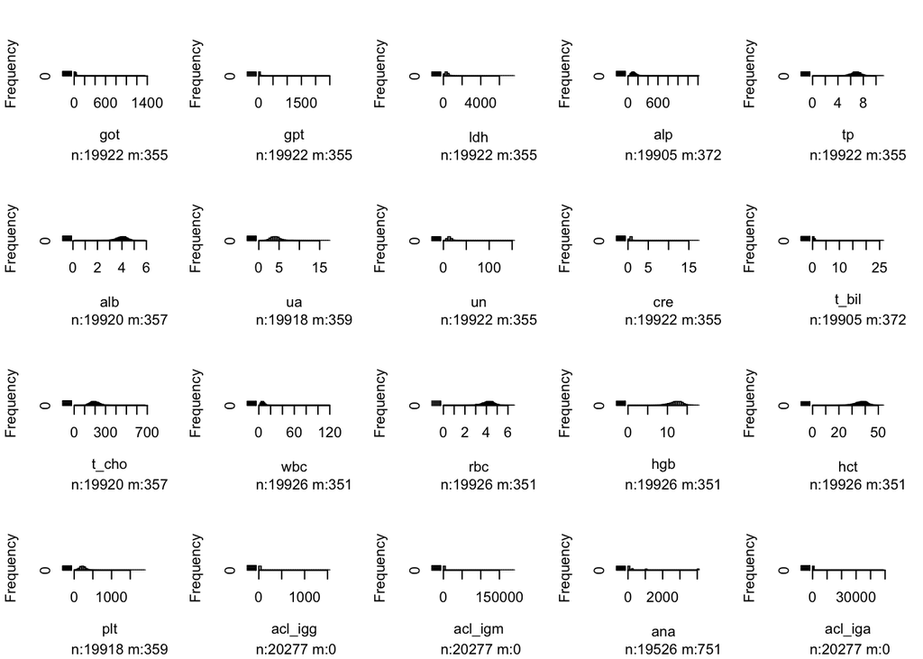

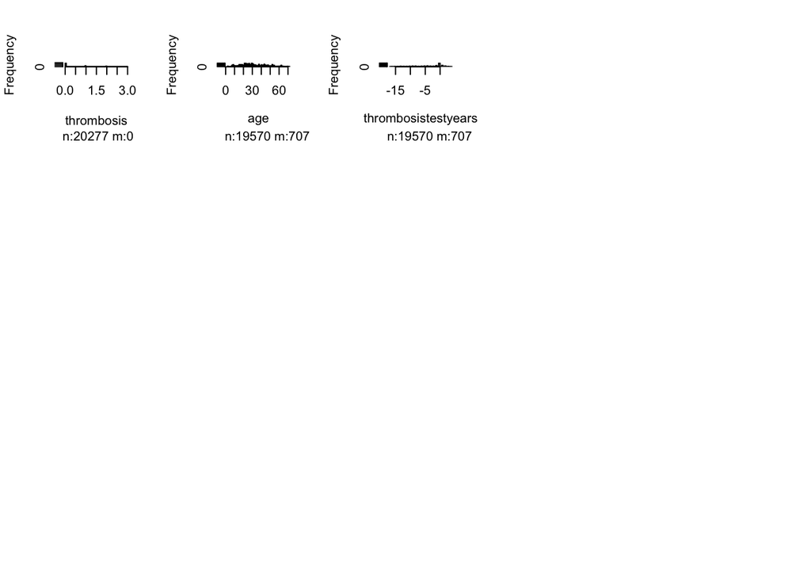

```r
# Histogram
hist.data.frame(data5 |> select(where(is.numeric)))
```

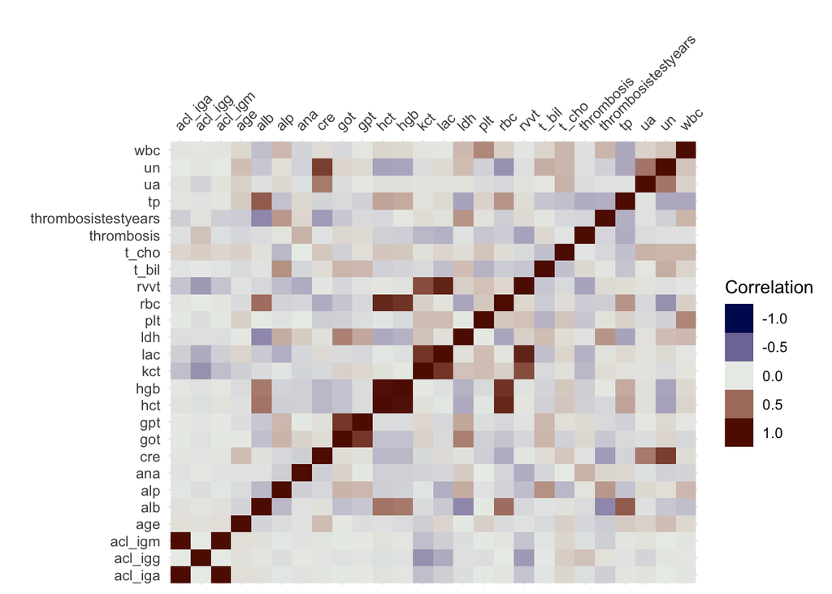

```r
# Correlation Plot
visdat::vis_cor(
  data5 %>% select(where(is.numeric))
)
```

# Plots Assignments

Q1. How does the level of thrombosis relate to the age and level of Creatinine?

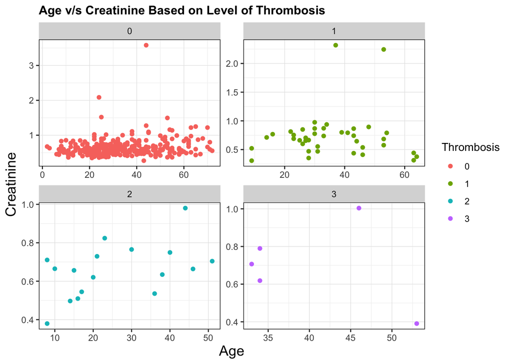

```r
ggplot(data5 %>% group_by(id) %>% summarise(cre_m = mean(cre), age_m=mean(age),throm = mean(thrombosis)),
aes(x=age_m, y=cre_m, color=factor(throm), na.rm = TRUE)) +
  geom_point(na.rm=TRUE) +
  facet_wrap(~throm,scales = "free", drop=TRUE)+
   labs(x = "Age", y = "Creatinine")+ # set axis labels
  theme(panel.border = element_rect(color = "black", fill = NA),
        panel.grid.major = element_line(colour = "grey90", size = 0.25), # grid lines
        panel.grid.minor = element_line(colour = "grey95"), # grid lines
        panel.background = element_blank(), # blank background
        legend.key = element_blank(), # remove legend key
        axis.title.x = element_text(color = "black", size = 14),
        axis.title.y = element_text(color = "black", size = 14),
        plot.title = element_text(size = 12, face = "bold"))+
  ggtitle("Age v/s Creatinine Based on Level of Thrombosis")+
     guides(color = guide_legend(title = "Thrombosis")) # add legend title
```

```r
ggsave("plot1.png")
```

Q2. What is the relationship between patient demographics (sex, admission status) and the presence of thrombosis, as measured by age and symptoms?

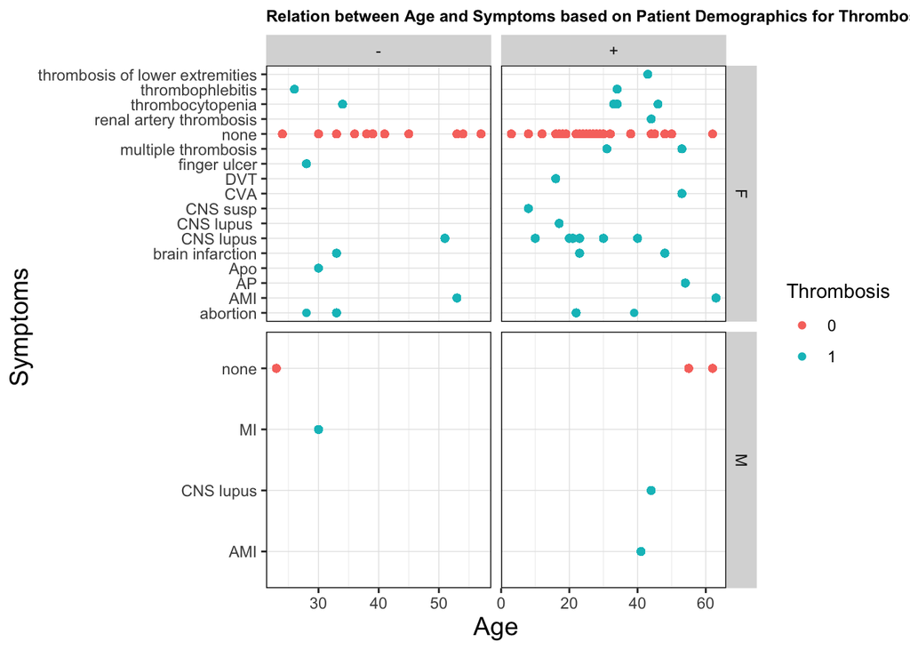

```r
ggplot(na.omit(data5)) +
  aes(age, symptoms, color = thrombosis_bol, na.rm = TRUE) +
  geom_point(na.rm = TRUE) +
  facet_grid(sex ~ admission, drop = TRUE, scales = "free")+
  labs(x = "Age", y = "Symptoms")+ # set axis labels
  theme(panel.border = element_rect(color = "black", fill = NA),
        panel.grid.major = element_line(colour = "grey90", size = 0.25), # grid lines
        panel.grid.minor = element_line(colour = "grey95"), # grid lines
        panel.background = element_blank(), # blank background
        legend.key = element_blank(), # remove legend key
        axis.title.x = element_text(color = "black", size = 14),
        axis.title.y = element_text(color = "black", size = 14),
        plot.title = element_text(size = 9, face = "bold"))+
    ggtitle("Relation between Age and Symptoms based on Patient Demographics for Thrombosis" )+
   guides(color = guide_legend(title = "Thrombosis")) # add legend title
```

```r
ggsave("plot2.png")
```

Q3. What is the relationship between the levels of Lactate Dehydrogenase (LDH) and the years from the Thrombosis Test?

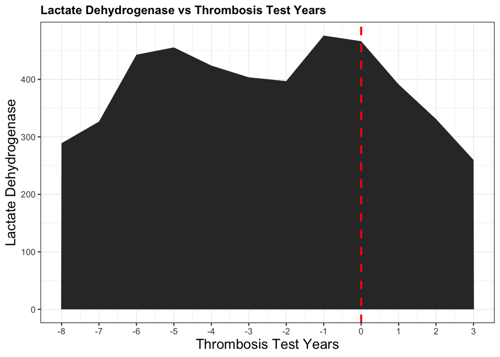

```r
data6<- data5 %>% group_by(thrombosistestyears) %>% summarise(ldh_avg = mean(ldh))
data6<- na.omit(data6)
data6<-data6[-c((1:5),18),]

ggplot(data6, aes(thrombosistestyears, ldh_avg)) +
  geom_area() +
  scale_y_continuous()+
  scale_x_continuous(breaks = seq(-8,3,1))+
  labs(title="Area Chart",
       y="Lactate Dehydrogenase",
       x="Thrombosis Test Years")+
  theme(panel.border = element_rect(color = "black", fill = NA),
        panel.grid.major = element_line(colour = "grey90", size = 0.25), # grid lines
        panel.grid.minor = element_line(colour = "grey95"), # grid lines
        panel.background = element_blank(), # blank background
        legend.key = element_blank(), # remove legend key
        axis.title.x = element_text(color = "black", size = 14),
        axis.title.y = element_text(color = "black", size = 14),
        plot.title = element_text(size = 12, face = "bold"))+
      geom_vline(xintercept =0, linetype="dashed", color = "red", size=1)+
  ggtitle("Lactate Dehydrogenase vs Thrombosis Test Years" )
```

```r
ggsave("plot3.png")
```

Q4. What is the relationship between levels of uric acid and urea nitrogen based on thrombosis and gender?

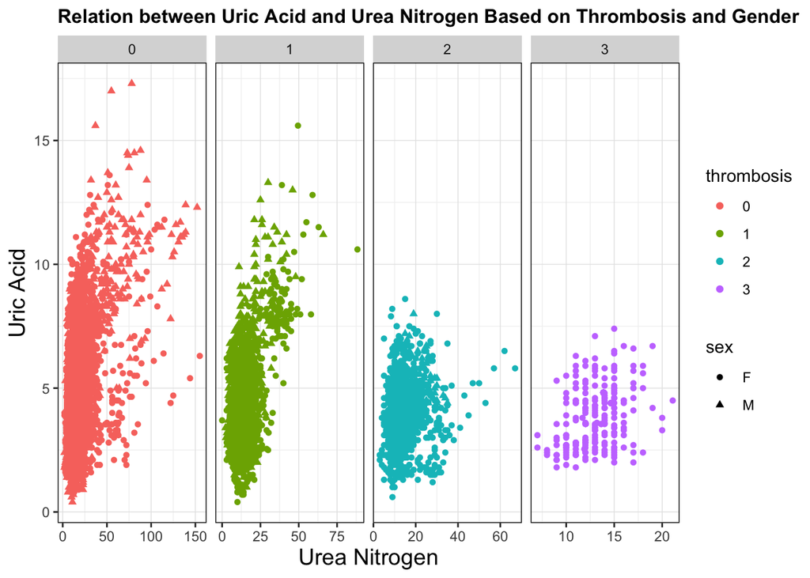

```r
ggplot(data5)+ aes(x=un, y=ua, color=factor(thrombosis),shape=sex, na.rm=T) +
  geom_point(na.rm = T)+
  facet_grid(~thrombosis, scales = "free", drop=T)+
   labs(title="Area Chart", y="Uric Acid", x="Urea Nitrogen")+
  theme(panel.border = element_rect(color = "black",fill=NA),
        panel.grid.major = element_line(colour = "grey90", size = 0.25), # grid lines
        panel.grid.minor = element_line(colour = "grey95"), # grid lines
        panel.background = element_blank(), # blank background
        legend.key = element_blank(), # remove legend key
        axis.title.x = element_text(color = "black", size = 14),
        axis.title.y = element_text(color = "black", size = 14),
        plot.title = element_text(size = 12, face = "bold"))+
        scale_shape_discrete(na.translate = F)+
    ggtitle("Relation between Uric Acid and Urea Nitrogen Based on Thrombosis and Gender" )+
  guides(color = guide_legend(title = "thrombosis")) # add legend title
```

```r
ggsave("plot4.png")
```